# Risk Factor Analysis

## Outcome Variable

**Outcome Variable:** wasted

## Predictor Variables

**Intervention Variable:** birthwt

**Adjustment Set:**

- arm
- sex
- W_mage
- meducyrs
- feducyrs
- vagbrth
- single
- brthmon
- W_parity
- delta_W_mage
- delta_meducyrs
- delta_feducyrs
- delta_vagbrth
- delta_single
- delta_brthmon
- delta_W_parity

## Stratifying Variables

The analysis was stratified on these variable(s):

- agecat
- studyid
- country

## Data Summary

| agecat | studyid | country | birthwt | wasted | n_cell | n |
| --- | --- | --- | --- | --- | --- | --- |
| Birth | ki0047075b-MAL-ED | BANGLADESH | Normal or high birthweight | 0 | 177 | 241 |
| Birth | ki0047075b-MAL-ED | BANGLADESH | Normal or high birthweight | 1 | 25 | 241 |
| Birth | ki0047075b-MAL-ED | BANGLADESH | Low birth weight | 0 | 24 | 241 |
| Birth | ki0047075b-MAL-ED | BANGLADESH | Low birth weight | 1 | 15 | 241 |
| Birth | ki0047075b-MAL-ED | BRAZIL | Normal or high birthweight | 0 | 174 | 183 |
| Birth | ki0047075b-MAL-ED | BRAZIL | Normal or high birthweight | 1 | 5 | 183 |
| Birth | ki0047075b-MAL-ED | BRAZIL | Low birth weight | 0 | 3 | 183 |
| Birth | ki0047075b-MAL-ED | BRAZIL | Low birth weight | 1 | 1 | 183 |
| Birth | ki0047075b-MAL-ED | INDIA | Normal or high birthweight | 0 | 152 | 203 |
| Birth | ki0047075b-MAL-ED | INDIA | Normal or high birthweight | 1 | 19 | 203 |
| Birth | ki0047075b-MAL-ED | INDIA | Low birth weight | 0 | 18 | 203 |
| Birth | ki0047075b-MAL-ED | INDIA | Low birth weight | 1 | 14 | 203 |
| Birth | ki0047075b-MAL-ED | NEPAL | Normal or high birthweight | 0 | 142 | 168 |
| Birth | ki0047075b-MAL-ED | NEPAL | Normal or high birthweight | 1 | 13 | 168 |
| Birth | ki0047075b-MAL-ED | NEPAL | Low birth weight | 0 | 6 | 168 |
| Birth | ki0047075b-MAL-ED | NEPAL | Low birth weight | 1 | 7 | 168 |
| Birth | ki0047075b-MAL-ED | PERU | Normal or high birthweight | 0 | 260 | 279 |
| Birth | ki0047075b-MAL-ED | PERU | Normal or high birthweight | 1 | 5 | 279 |
| Birth | ki0047075b-MAL-ED | PERU | Low birth weight | 0 | 13 | 279 |
| Birth | ki0047075b-MAL-ED | PERU | Low birth weight | 1 | 1 | 279 |
| Birth | ki0047075b-MAL-ED | SOUTH AFRICA | Normal or high birthweight | 0 | 231 | 258 |
| Birth | ki0047075b-MAL-ED | SOUTH AFRICA | Normal or high birthweight | 1 | 13 | 258 |
| Birth | ki0047075b-MAL-ED | SOUTH AFRICA | Low birth weight | 0 | 9 | 258 |
| Birth | ki0047075b-MAL-ED | SOUTH AFRICA | Low birth weight | 1 | 5 | 258 |
| Birth | ki0047075b-MAL-ED | TANZANIA, UNITED REPUBLIC OF | Normal or high birthweight | 0 | 112 | 118 |
| Birth | ki0047075b-MAL-ED | TANZANIA, UNITED REPUBLIC OF | Normal or high birthweight | 1 | 1 | 118 |
| Birth | ki0047075b-MAL-ED | TANZANIA, UNITED REPUBLIC OF | Low birth weight | 0 | 4 | 118 |
| Birth | ki0047075b-MAL-ED | TANZANIA, UNITED REPUBLIC OF | Low birth weight | 1 | 1 | 118 |
| Birth | ki1000108-CMC-V-BCS-2002 | INDIA | Normal or high birthweight | 0 | 70 | 88 |
| Birth | ki1000108-CMC-V-BCS-2002 | INDIA | Normal or high birthweight | 1 | 9 | 88 |

[output cut: 286 more lines]

The following strata were considered:

- agecat: 24 months, studyid: ki0047075b-MAL-ED, country: BANGLADESH
- agecat: 24 months, studyid: ki0047075b-MAL-ED, country: BRAZIL
- agecat: 24 months, studyid: ki0047075b-MAL-ED, country: INDIA
- agecat: 24 months, studyid: ki0047075b-MAL-ED, country: NEPAL
- agecat: 24 months, studyid: ki0047075b-MAL-ED, country: PERU
- agecat: 24 months, studyid: ki0047075b-MAL-ED, country: SOUTH AFRICA
- agecat: 24 months, studyid: ki0047075b-MAL-ED, country: TANZANIA, UNITED REPUBLIC OF
- agecat: 24 months, studyid: ki1000108-CMC-V-BCS-2002, country: INDIA
- agecat: 24 months, studyid: ki1000108-IRC, country: INDIA
- agecat: 24 months, studyid: ki1017093-NIH-Birth, country: BANGLADESH
- agecat: 24 months, studyid: ki1017093b-PROVIDE, country: BANGLADESH
- agecat: 24 months, studyid: ki1017093c-NIH-Crypto, country: BANGLADESH
- agecat: 24 months, studyid: ki1066203-TanzaniaChild2, country: TANZANIA, UNITED REPUBLIC OF
- agecat: 24 months, studyid: ki1101329-Keneba, country: GAMBIA
- agecat: 24 months, studyid: ki1114097-CMIN, country: BANGLADESH
- agecat: 24 months, studyid: ki1114097-CMIN, country: PERU
- agecat: 24 months, studyid: ki1114097-CONTENT, country: PERU
- agecat: 24 months, studyid: ki1119695-PROBIT, country: BELARUS
- agecat: 24 months, studyid: ki1126311-ZVITAMBO, country: ZIMBABWE
- agecat: 24 months, studyid: ki1135781-COHORTS, country: GUATEMALA
- agecat: 24 months, studyid: ki1135781-COHORTS, country: INDIA
- agecat: 24 months, studyid: ki1135781-COHORTS, country: PHILIPPINES
- agecat: 24 months, studyid: kiGH5241-JiVitA-3, country: BANGLADESH
- agecat: 24 months, studyid: kiGH5241-JiVitA-4, country: BANGLADESH
- agecat: 6 months, studyid: ki0047075b-MAL-ED, country: BANGLADESH
- agecat: 6 months, studyid: ki0047075b-MAL-ED, country: BRAZIL
- agecat: 6 months, studyid: ki0047075b-MAL-ED, country: INDIA
- agecat: 6 months, studyid: ki0047075b-MAL-ED, country: NEPAL
- agecat: 6 months, studyid: ki0047075b-MAL-ED, country: PERU
- agecat: 6 months, studyid: ki0047075b-MAL-ED, country: SOUTH AFRICA
- agecat: 6 months, studyid: ki0047075b-MAL-ED, country: TANZANIA, UNITED REPUBLIC OF
- agecat: 6 months, studyid: ki1000108-CMC-V-BCS-2002, country: INDIA
- agecat: 6 months, studyid: ki1000108-IRC, country: INDIA
- agecat: 6 months, studyid: ki1000109-EE, country: PAKISTAN
- agecat: 6 months, studyid: ki1000109-ResPak, country: PAKISTAN
- agecat: 6 months, studyid: ki1000304b-SAS-CompFeed, country: INDIA
- agecat: 6 months, studyid: ki1017093-NIH-Birth, country: BANGLADESH
- agecat: 6 months, studyid: ki1017093b-PROVIDE, country: BANGLADESH
- agecat: 6 months, studyid: ki1017093c-NIH-Crypto, country: BANGLADESH
- agecat: 6 months, studyid: ki1066203-TanzaniaChild2, country: TANZANIA, UNITED REPUBLIC OF
- agecat: 6 months, studyid: ki1101329-Keneba, country: GAMBIA
- agecat: 6 months, studyid: ki1114097-CMIN, country: BANGLADESH
- agecat: 6 months, studyid: ki1114097-CMIN, country: BRAZIL
- agecat: 6 months, studyid: ki1114097-CMIN, country: GUINEA-BISSAU
- agecat: 6 months, studyid: ki1114097-CMIN, country: PERU
- agecat: 6 months, studyid: ki1114097-CONTENT, country: PERU
- agecat: 6 months, studyid: ki1119695-PROBIT, country: BELARUS
- agecat: 6 months, studyid: ki1126311-ZVITAMBO, country: ZIMBABWE
- agecat: 6 months, studyid: ki1135781-COHORTS, country: GUATEMALA
- agecat: 6 months, studyid: ki1135781-COHORTS, country: INDIA
- agecat: 6 months, studyid: ki1135781-COHORTS, country: PHILIPPINES
- agecat: 6 months, studyid: kiGH5241-JiVitA-3, country: BANGLADESH
- agecat: 6 months, studyid: kiGH5241-JiVitA-4, country: BANGLADESH
- agecat: Birth, studyid: ki0047075b-MAL-ED, country: BANGLADESH
- agecat: Birth, studyid: ki0047075b-MAL-ED, country: BRAZIL
- agecat: Birth, studyid: ki0047075b-MAL-ED, country: INDIA
- agecat: Birth, studyid: ki0047075b-MAL-ED, country: NEPAL
- agecat: Birth, studyid: ki0047075b-MAL-ED, country: PERU
- agecat: Birth, studyid: ki0047075b-MAL-ED, country: SOUTH AFRICA
- agecat: Birth, studyid: ki0047075b-MAL-ED, country: TANZANIA, UNITED REPUBLIC OF
- agecat: Birth, studyid: ki1000108-CMC-V-BCS-2002, country: INDIA
- agecat: Birth, studyid: ki1000108-IRC, country: INDIA
- agecat: Birth, studyid: ki1000109-EE, country: PAKISTAN
- agecat: Birth, studyid: ki1000109-ResPak, country: PAKISTAN
- agecat: Birth, studyid: ki1000304b-SAS-CompFeed, country: INDIA
- agecat: Birth, studyid: ki1017093-NIH-Birth, country: BANGLADESH
- agecat: Birth, studyid: ki1017093c-NIH-Crypto, country: BANGLADESH
- agecat: Birth, studyid: ki1101329-Keneba, country: GAMBIA
- agecat: Birth, studyid: ki1114097-CMIN, country: BANGLADESH
- agecat: Birth, studyid: ki1114097-CMIN, country: BRAZIL
- agecat: Birth, studyid: ki1114097-CMIN, country: PERU
- agecat: Birth, studyid: ki1114097-CONTENT, country: PERU
- agecat: Birth, studyid: ki1119695-PROBIT, country: BELARUS
- agecat: Birth, studyid: ki1126311-ZVITAMBO, country: ZIMBABWE
- agecat: Birth, studyid: ki1135781-COHORTS, country: GUATEMALA
- agecat: Birth, studyid: ki1135781-COHORTS, country: INDIA
- agecat: Birth, studyid: ki1135781-COHORTS, country: PHILIPPINES
- agecat: Birth, studyid: kiGH5241-JiVitA-3, country: BANGLADESH
- agecat: Birth, studyid: kiGH5241-JiVitA-4, country: BANGLADESH

### Dropped Strata

Some strata were dropped due to rare outcomes:

- agecat: Birth, studyid: ki0047075b-MAL-ED, country: BRAZIL
- agecat: Birth, studyid: ki0047075b-MAL-ED, country: PERU
- agecat: Birth, studyid: ki0047075b-MAL-ED, country: TANZANIA, UNITED REPUBLIC OF
- agecat: Birth, studyid: ki1000108-CMC-V-BCS-2002, country: INDIA
- agecat: Birth, studyid: ki1000109-EE, country: PAKISTAN
- agecat: Birth, studyid: ki1000109-ResPak, country: PAKISTAN
- agecat: Birth, studyid: ki1000304b-SAS-CompFeed, country: INDIA
- agecat: Birth, studyid: ki1017093-NIH-Birth, country: BANGLADESH
- agecat: Birth, studyid: ki1017093c-NIH-Crypto, country: BANGLADESH
- agecat: Birth, studyid: ki1114097-CMIN, country: BANGLADESH
- agecat: Birth, studyid: ki1114097-CMIN, country: BRAZIL
- agecat: Birth, studyid: ki1114097-CMIN, country: PERU
- agecat: Birth, studyid: ki1114097-CONTENT, country: PERU
- agecat: Birth, studyid: ki1119695-PROBIT, country: BELARUS
- agecat: 6 months, studyid: ki0047075b-MAL-ED, country: BANGLADESH
- agecat: 6 months, studyid: ki0047075b-MAL-ED, country: BRAZIL
- agecat: 6 months, studyid: ki0047075b-MAL-ED, country: INDIA
- agecat: 6 months, studyid: ki0047075b-MAL-ED, country: NEPAL
- agecat: 6 months, studyid: ki0047075b-MAL-ED, country: PERU
- agecat: 6 months, studyid: ki0047075b-MAL-ED, country: SOUTH AFRICA
- agecat: 6 months, studyid: ki0047075b-MAL-ED, country: TANZANIA, UNITED REPUBLIC OF
- agecat: 6 months, studyid: ki1000109-ResPak, country: PAKISTAN
- agecat: 6 months, studyid: ki1066203-TanzaniaChild2, country: TANZANIA, UNITED REPUBLIC OF
- agecat: 6 months, studyid: ki1114097-CMIN, country: BANGLADESH
- agecat: 6 months, studyid: ki1114097-CMIN, country: BRAZIL
- agecat: 6 months, studyid: ki1114097-CMIN, country: GUINEA-BISSAU
- agecat: 6 months, studyid: ki1114097-CMIN, country: PERU
- agecat: 6 months, studyid: ki1114097-CONTENT, country: PERU
- agecat: 6 months, studyid: ki1119695-PROBIT, country: BELARUS
- agecat: 6 months, studyid: ki1135781-COHORTS, country: GUATEMALA
- agecat: 24 months, studyid: ki0047075b-MAL-ED, country: BANGLADESH
- agecat: 24 months, studyid: ki0047075b-MAL-ED, country: BRAZIL
- agecat: 24 months, studyid: ki0047075b-MAL-ED, country: NEPAL
- agecat: 24 months, studyid: ki0047075b-MAL-ED, country: PERU
- agecat: 24 months, studyid: ki0047075b-MAL-ED, country: SOUTH AFRICA
- agecat: 24 months, studyid: ki0047075b-MAL-ED, country: TANZANIA, UNITED REPUBLIC OF
- agecat: 24 months, studyid: ki1066203-TanzaniaChild2, country: TANZANIA, UNITED REPUBLIC OF
- agecat: 24 months, studyid: ki1114097-CMIN, country: BANGLADESH
- agecat: 24 months, studyid: ki1114097-CMIN, country: PERU
- agecat: 24 months, studyid: ki1114097-CONTENT, country: PERU
- agecat: 24 months, studyid: ki1119695-PROBIT, country: BELARUS

## Methods Detail

We’re interested in the causal parameters $E[Y_a]$ for all values of $a \in \mathcal{A}$. These parameters represent the mean outcome if, possibly contrary to fact, we intervened to set all units to have $A=a$. Under the randomization and positivity assumptions, these are identified by the statistical parameters $\psi_a=E_W[E_{Y|A,W}(Y|A=a,W)]$. In addition, we’re interested in the mean of $Y$, $E[Y]$ under no intervention (the observed mean). We will estimate these parameters by using SuperLearner to fit the relevant likelihood factors – $E_{Y|A,W}(Y|A=a,W)$ and $p(A=a|W)$, and then updating our likelihood fit using a joint TMLE.

For unadjusted analyses ($W=\{\}$), initial likelihoods were estimated using Lrnr_glm to estimate the simple $E(Y|A)$ and Lrnr_mean to estimate $p(A)$. For adjusted analyses, a small library containing Lrnr_glmnet, Lrnr_xgboost, and Lrnr_mean was used.

Having estimated these parameters, we will then use the delta method to estimate relative risks and attributable risks relative to a prespecified baseline level of $A$.

# Results Detail

## Results Plots

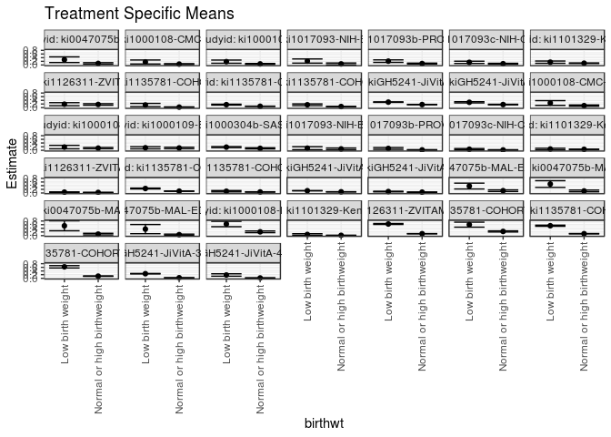

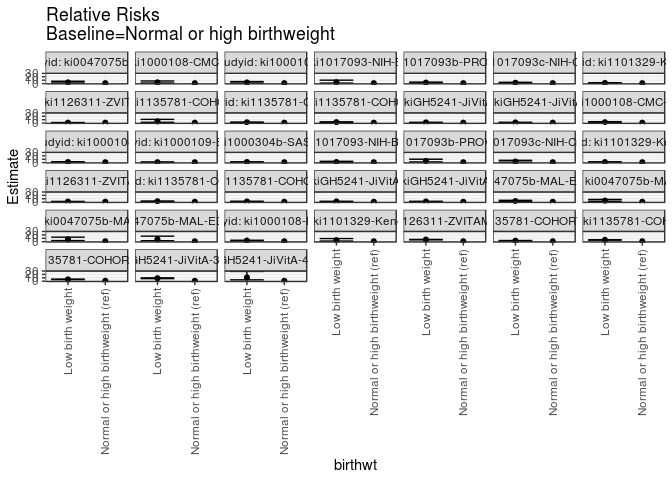

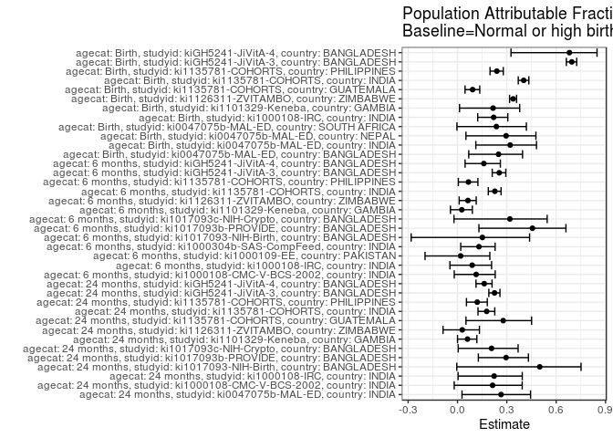

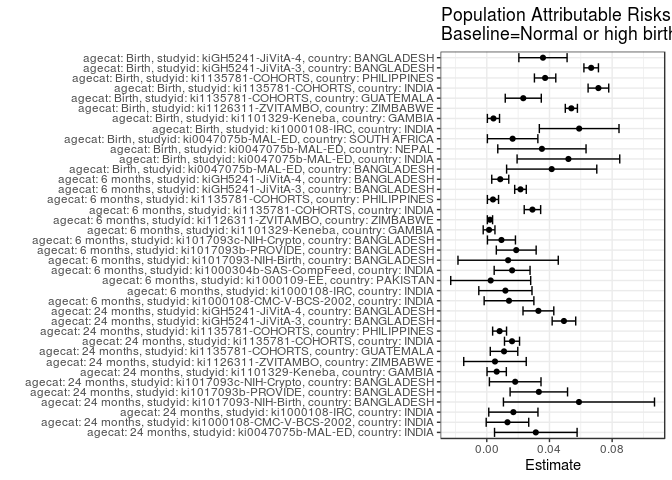

## Results Table

### Parameter: TSM

| agecat | studyid | country | intervention_level | baseline_level | estimate | ci_lower | ci_upper |
| --- | --- | --- | --- | --- | --- | --- | --- |
| Birth | ki0047075b-MAL-ED | BANGLADESH | Normal or high birthweight | NA | 0.1245537 | 0.0789212 | 0.1701862 |
| Birth | ki0047075b-MAL-ED | BANGLADESH | Low birth weight | NA | 0.3782421 | 0.2183574 | 0.5381269 |
| Birth | ki0047075b-MAL-ED | INDIA | Normal or high birthweight | NA | 0.1104680 | 0.0633111 | 0.1576248 |
| Birth | ki0047075b-MAL-ED | INDIA | Low birth weight | NA | 0.4884216 | 0.3050435 | 0.6717996 |
| Birth | ki0047075b-MAL-ED | NEPAL | Normal or high birthweight | NA | 0.0838710 | 0.0401024 | 0.1276396 |
| Birth | ki0047075b-MAL-ED | NEPAL | Low birth weight | NA | 0.5384615 | 0.2666586 | 0.8102645 |
| Birth | ki0047075b-MAL-ED | SOUTH AFRICA | Normal or high birthweight | NA | 0.0532787 | 0.0250439 | 0.0815135 |
| Birth | ki0047075b-MAL-ED | SOUTH AFRICA | Low birth weight | NA | 0.3571429 | 0.1056616 | 0.6086241 |
| Birth | ki1000108-IRC | INDIA | Normal or high birthweight | NA | 0.2092692 | 0.1628590 | 0.2556795 |
| Birth | ki1000108-IRC | INDIA | Low birth weight | NA | 0.6357829 | 0.4889089 | 0.7826569 |
| Birth | ki1101329-Keneba | GAMBIA | Normal or high birthweight | NA | 0.0154202 | 0.0087121 | 0.0221283 |
| Birth | ki1101329-Keneba | GAMBIA | Low birth weight | NA | 0.0634921 | 0.0208998 | 0.1060843 |
| Birth | ki1126311-ZVITAMBO | ZIMBABWE | Normal or high birthweight | NA | 0.1055246 | 0.0999331 | 0.1111162 |
| Birth | ki1126311-ZVITAMBO | ZIMBABWE | Low birth weight | NA | 0.6372914 | 0.6104368 | 0.6641460 |
| Birth | ki1135781-COHORTS | GUATEMALA | Normal or high birthweight | NA | 0.2306858 | 0.1994954 | 0.2618761 |
| Birth | ki1135781-COHORTS | GUATEMALA | Low birth weight | NA | 0.6004341 | 0.4633342 | 0.7375339 |
| Birth | ki1135781-COHORTS | INDIA | Normal or high birthweight | NA | 0.1057415 | 0.0973608 | 0.1141223 |
| Birth | ki1135781-COHORTS | INDIA | Low birth weight | NA | 0.5423756 | 0.5115500 | 0.5732011 |
| Birth | ki1135781-COHORTS | PHILIPPINES | Normal or high birthweight | NA | 0.1183552 | 0.1061414 | 0.1305691 |
| Birth | ki1135781-COHORTS | PHILIPPINES | Low birth weight | NA | 0.6286557 | 0.5632675 | 0.6940438 |
| Birth | kiGH5241-JiVitA-3 | BANGLADESH | Normal or high birthweight | NA | 0.0292540 | 0.0258135 | 0.0326944 |
| Birth | kiGH5241-JiVitA-3 | BANGLADESH | Low birth weight | NA | 0.2514882 | 0.2377024 | 0.2652741 |
| Birth | kiGH5241-JiVitA-4 | BANGLADESH | Normal or high birthweight | NA | 0.0168539 | 0.0014406 | 0.0322673 |
| Birth | kiGH5241-JiVitA-4 | BANGLADESH | Low birth weight | NA | 0.1812081 | 0.1157680 | 0.2466481 |
| 6 months | ki1000108-CMC-V-BCS-2002 | INDIA | Normal or high birthweight | NA | 0.1108150 | 0.0766293 | 0.1450008 |
| 6 months | ki1000108-CMC-V-BCS-2002 | INDIA | Low birth weight | NA | 0.2546662 | 0.1251907 | 0.3841417 |
| 6 months | ki1000108-IRC | INDIA | Normal or high birthweight | NA | 0.1211274 | 0.0862317 | 0.1560232 |
| 6 months | ki1000108-IRC | INDIA | Low birth weight | NA | 0.1775703 | 0.0832883 | 0.2718524 |
| 6 months | ki1000109-EE | PAKISTAN | Normal or high birthweight | NA | 0.1278176 | 0.0857776 | 0.1698577 |
| 6 months | ki1000109-EE | PAKISTAN | Low birth weight | NA | 0.1393315 | 0.0795329 | 0.1991302 |
| 6 months | ki1000304b-SAS-CompFeed | INDIA | Normal or high birthweight | NA | 0.1077042 | 0.0770646 | 0.1383437 |
| 6 months | ki1000304b-SAS-CompFeed | INDIA | Low birth weight | NA | 0.1742688 | 0.1426657 | 0.2058719 |
| 6 months | ki1017093-NIH-Birth | BANGLADESH | Normal or high birthweight | NA | 0.0762712 | 0.0282445 | 0.1242979 |
| 6 months | ki1017093-NIH-Birth | BANGLADESH | Low birth weight | NA | 0.1166667 | 0.0352091 | 0.1981243 |
| 6 months | ki1017093b-PROVIDE | BANGLADESH | Normal or high birthweight | NA | 0.0224426 | 0.0085784 | 0.0363068 |
| 6 months | ki1017093b-PROVIDE | BANGLADESH | Low birth weight | NA | 0.1028938 | 0.0529537 | 0.1528339 |
| 6 months | ki1017093c-NIH-Crypto | BANGLADESH | Normal or high birthweight | NA | 0.0200164 | 0.0082022 | 0.0318306 |
| 6 months | ki1017093c-NIH-Crypto | BANGLADESH | Low birth weight | NA | 0.0589799 | 0.0234581 | 0.0945018 |
| 6 months | ki1101329-Keneba | GAMBIA | Normal or high birthweight | NA | 0.0547675 | 0.0434987 | 0.0660363 |
| 6 months | ki1101329-Keneba | GAMBIA | Low birth weight | NA | 0.0707208 | 0.0286655 | 0.1127762 |
| 6 months | ki1126311-ZVITAMBO | ZIMBABWE | Normal or high birthweight | NA | 0.0300281 | 0.0260814 | 0.0339748 |
| 6 months | ki1126311-ZVITAMBO | ZIMBABWE | Low birth weight | NA | 0.0458313 | 0.0330794 | 0.0585832 |
| 6 months | ki1135781-COHORTS | INDIA | Normal or high birthweight | NA | 0.0991474 | 0.0908535 | 0.1074413 |
| 6 months | ki1135781-COHORTS | INDIA | Low birth weight | NA | 0.2450292 | 0.2211716 | 0.2688867 |
| 6 months | ki1135781-COHORTS | PHILIPPINES | Normal or high birthweight | NA | 0.0553649 | 0.0462350 | 0.0644947 |
| 6 months | ki1135781-COHORTS | PHILIPPINES | Low birth weight | NA | 0.0959537 | 0.0595684 | 0.1323390 |
| 6 months | kiGH5241-JiVitA-3 | BANGLADESH | Normal or high birthweight | NA | 0.0632832 | 0.0582290 | 0.0683373 |
| 6 months | kiGH5241-JiVitA-3 | BANGLADESH | Low birth weight | NA | 0.1230219 | 0.1136737 | 0.1323701 |
| 6 months | kiGH5241-JiVitA-4 | BANGLADESH | Normal or high birthweight | NA | 0.0450512 | 0.0336567 | 0.0564456 |
| 6 months | kiGH5241-JiVitA-4 | BANGLADESH | Low birth weight | NA | 0.0786724 | 0.0607678 | 0.0965769 |
| 24 months | ki0047075b-MAL-ED | INDIA | Normal or high birthweight | NA | 0.0868920 | 0.0462657 | 0.1275183 |
| 24 months | ki0047075b-MAL-ED | INDIA | Low birth weight | NA | 0.2890214 | 0.1343629 | 0.4436799 |
| 24 months | ki1000108-CMC-V-BCS-2002 | INDIA | Normal or high birthweight | NA | 0.0486322 | 0.0253582 | 0.0719062 |
| 24 months | ki1000108-CMC-V-BCS-2002 | INDIA | Low birth weight | NA | 0.1627907 | 0.0522989 | 0.2732825 |
| 24 months | ki1000108-IRC | INDIA | Normal or high birthweight | NA | 0.0592066 | 0.0341062 | 0.0843071 |
| 24 months | ki1000108-IRC | INDIA | Low birth weight | NA | 0.1825532 | 0.0952394 | 0.2698670 |
| 24 months | ki1017093-NIH-Birth | BANGLADESH | Normal or high birthweight | NA | 0.0588235 | 0.0086179 | 0.1090291 |
| 24 months | ki1017093-NIH-Birth | BANGLADESH | Low birth weight | NA | 0.2156863 | 0.1023884 | 0.3289841 |
| 24 months | ki1017093b-PROVIDE | BANGLADESH | Normal or high birthweight | NA | 0.0792469 | 0.0538838 | 0.1046100 |
| 24 months | ki1017093b-PROVIDE | BANGLADESH | Low birth weight | NA | 0.2106410 | 0.1419259 | 0.2793562 |
| 24 months | ki1017093c-NIH-Crypto | BANGLADESH | Normal or high birthweight | NA | 0.0694159 | 0.0440810 | 0.0947507 |
| 24 months | ki1017093c-NIH-Crypto | BANGLADESH | Low birth weight | NA | 0.1455329 | 0.0836682 | 0.2073975 |
| 24 months | ki1101329-Keneba | GAMBIA | Normal or high birthweight | NA | 0.0974491 | 0.0813323 | 0.1135660 |
| 24 months | ki1101329-Keneba | GAMBIA | Low birth weight | NA | 0.1543609 | 0.0926337 | 0.2160882 |
| 24 months | ki1126311-ZVITAMBO | ZIMBABWE | Normal or high birthweight | NA | 0.1752912 | 0.1341298 | 0.2164526 |
| 24 months | ki1126311-ZVITAMBO | ZIMBABWE | Low birth weight | NA | 0.1897914 | 0.1069101 | 0.2726727 |
| 24 months | ki1135781-COHORTS | GUATEMALA | Normal or high birthweight | NA | 0.0285714 | 0.0151749 | 0.0419679 |
| 24 months | ki1135781-COHORTS | GUATEMALA | Low birth weight | NA | 0.1451613 | 0.0574106 | 0.2329120 |
| 24 months | ki1135781-COHORTS | INDIA | Normal or high birthweight | NA | 0.0747496 | 0.0664959 | 0.0830033 |
| 24 months | ki1135781-COHORTS | INDIA | Low birth weight | NA | 0.1635626 | 0.1395038 | 0.1876214 |
| 24 months | ki1135781-COHORTS | PHILIPPINES | Normal or high birthweight | NA | 0.0598764 | 0.0499247 | 0.0698281 |
| 24 months | ki1135781-COHORTS | PHILIPPINES | Low birth weight | NA | 0.1569477 | 0.1089035 | 0.2049920 |
| 24 months | kiGH5241-JiVitA-3 | BANGLADESH | Normal or high birthweight | NA | 0.1694729 | 0.1582914 | 0.1806543 |
| 24 months | kiGH5241-JiVitA-3 | BANGLADESH | Low birth weight | NA | 0.3027044 | 0.2857372 | 0.3196716 |
| 24 months | kiGH5241-JiVitA-4 | BANGLADESH | Normal or high birthweight | NA | 0.1694634 | 0.1527638 | 0.1861629 |
| 24 months | kiGH5241-JiVitA-4 | BANGLADESH | Low birth weight | NA | 0.2937831 | 0.2613476 | 0.3262186 |

### Parameter: E(Y)

| agecat | studyid | country | intervention_level | baseline_level | estimate | ci_lower | ci_upper |
| --- | --- | --- | --- | --- | --- | --- | --- |
| Birth | ki0047075b-MAL-ED | BANGLADESH | NA | NA | 0.1659751 | 0.1189041 | 0.2130461 |
| Birth | ki0047075b-MAL-ED | INDIA | NA | NA | 0.1625616 | 0.1116803 | 0.2134428 |
| Birth | ki0047075b-MAL-ED | NEPAL | NA | NA | 0.1190476 | 0.0699312 | 0.1681640 |
| Birth | ki0047075b-MAL-ED | SOUTH AFRICA | NA | NA | 0.0697674 | 0.0386213 | 0.1009135 |
| Birth | ki1000108-IRC | INDIA | NA | NA | 0.2682216 | 0.2212677 | 0.3151755 |
| Birth | ki1101329-Keneba | GAMBIA | NA | NA | 0.0196767 | 0.0124580 | 0.0268954 |
| Birth | ki1126311-ZVITAMBO | ZIMBABWE | NA | NA | 0.1594921 | 0.1531776 | 0.1658066 |
| Birth | ki1135781-COHORTS | GUATEMALA | NA | NA | 0.2539683 | 0.2229196 | 0.2850169 |
| Birth | ki1135781-COHORTS | INDIA | NA | NA | 0.1769740 | 0.1674681 | 0.1864799 |
| Birth | ki1135781-COHORTS | PHILIPPINES | NA | NA | 0.1555709 | 0.1423748 | 0.1687670 |
| Birth | kiGH5241-JiVitA-3 | BANGLADESH | NA | NA | 0.0958686 | 0.0906699 | 0.1010673 |
| Birth | kiGH5241-JiVitA-4 | BANGLADESH | NA | NA | 0.0527086 | 0.0336587 | 0.0717585 |
| 6 months | ki1000108-CMC-V-BCS-2002 | INDIA | NA | NA | 0.1250000 | 0.0911644 | 0.1588356 |
| 6 months | ki1000108-IRC | INDIA | NA | NA | 0.1330049 | 0.0999328 | 0.1660771 |
| 6 months | ki1000109-EE | PAKISTAN | NA | NA | 0.1303191 | 0.0962457 | 0.1643926 |
| 6 months | ki1000304b-SAS-CompFeed | INDIA | NA | NA | 0.1238671 | 0.0990601 | 0.1486741 |
| 6 months | ki1017093-NIH-Birth | BANGLADESH | NA | NA | 0.0898876 | 0.0477511 | 0.1320242 |
| 6 months | ki1017093b-PROVIDE | BANGLADESH | NA | NA | 0.0412371 | 0.0250690 | 0.0574052 |
| 6 months | ki1017093c-NIH-Crypto | BANGLADESH | NA | NA | 0.0293706 | 0.0169860 | 0.0417552 |
| 6 months | ki1101329-Keneba | GAMBIA | NA | NA | 0.0562319 | 0.0453575 | 0.0671062 |
| 6 months | ki1126311-ZVITAMBO | ZIMBABWE | NA | NA | 0.0320622 | 0.0282569 | 0.0358675 |
| 6 months | ki1135781-COHORTS | INDIA | NA | NA | 0.1282790 | 0.1199892 | 0.1365687 |
| 6 months | ki1135781-COHORTS | PHILIPPINES | NA | NA | 0.0593093 | 0.0503382 | 0.0682804 |
| 6 months | kiGH5241-JiVitA-3 | BANGLADESH | NA | NA | 0.0847894 | 0.0799656 | 0.0896132 |
| 6 months | kiGH5241-JiVitA-4 | BANGLADESH | NA | NA | 0.0536465 | 0.0439582 | 0.0633347 |
| 24 months | ki0047075b-MAL-ED | INDIA | NA | NA | 0.1181818 | 0.0754264 | 0.1609372 |
| 24 months | ki1000108-CMC-V-BCS-2002 | INDIA | NA | NA | 0.0618280 | 0.0373207 | 0.0863352 |
| 24 months | ki1000108-IRC | INDIA | NA | NA | 0.0761671 | 0.0503644 | 0.1019698 |
| 24 months | ki1017093-NIH-Birth | BANGLADESH | NA | NA | 0.1176471 | 0.0632979 | 0.1719962 |
| 24 months | ki1017093b-PROVIDE | BANGLADESH | NA | NA | 0.1124567 | 0.0866788 | 0.1382347 |
| 24 months | ki1017093c-NIH-Crypto | BANGLADESH | NA | NA | 0.0875486 | 0.0630907 | 0.1120065 |
| 24 months | ki1101329-Keneba | GAMBIA | NA | NA | 0.1037604 | 0.0879825 | 0.1195384 |
| 24 months | ki1126311-ZVITAMBO | ZIMBABWE | NA | NA | 0.1805226 | 0.1437387 | 0.2173065 |
| 24 months | ki1135781-COHORTS | GUATEMALA | NA | NA | 0.0395738 | 0.0246551 | 0.0544926 |
| 24 months | ki1135781-COHORTS | INDIA | NA | NA | 0.0908525 | 0.0827390 | 0.0989661 |
| 24 months | ki1135781-COHORTS | PHILIPPINES | NA | NA | 0.0680498 | 0.0579935 | 0.0781061 |
| 24 months | kiGH5241-JiVitA-3 | BANGLADESH | NA | NA | 0.2187025 | 0.2087401 | 0.2286649 |
| 24 months | kiGH5241-JiVitA-4 | BANGLADESH | NA | NA | 0.2024018 | 0.1878193 | 0.2169843 |

### Parameter: RR

| agecat | studyid | country | intervention_level | baseline_level | estimate | ci_lower | ci_upper |
| --- | --- | --- | --- | --- | --- | --- | --- |
| Birth | ki0047075b-MAL-ED | BANGLADESH | Normal or high birthweight | Normal or high birthweight | 1.000000 | 1.0000000 | 1.000000 |
| Birth | ki0047075b-MAL-ED | BANGLADESH | Low birth weight | Normal or high birthweight | 3.036780 | 1.7297809 | 5.331329 |
| Birth | ki0047075b-MAL-ED | INDIA | Normal or high birthweight | Normal or high birthweight | 1.000000 | 1.0000000 | 1.000000 |
| Birth | ki0047075b-MAL-ED | INDIA | Low birth weight | Normal or high birthweight | 4.421386 | 2.4864714 | 7.862007 |
| Birth | ki0047075b-MAL-ED | NEPAL | Normal or high birthweight | Normal or high birthweight | 1.000000 | 1.0000000 | 1.000000 |
| Birth | ki0047075b-MAL-ED | NEPAL | Low birth weight | Normal or high birthweight | 6.420118 | 3.1061893 | 13.269610 |
| Birth | ki0047075b-MAL-ED | SOUTH AFRICA | Normal or high birthweight | Normal or high birthweight | 1.000000 | 1.0000000 | 1.000000 |
| Birth | ki0047075b-MAL-ED | SOUTH AFRICA | Low birth weight | Normal or high birthweight | 6.703297 | 2.7768391 | 16.181775 |
| Birth | ki1000108-IRC | INDIA | Normal or high birthweight | Normal or high birthweight | 1.000000 | 1.0000000 | 1.000000 |
| Birth | ki1000108-IRC | INDIA | Low birth weight | Normal or high birthweight | 3.038110 | 2.2045107 | 4.186920 |
| Birth | ki1101329-Keneba | GAMBIA | Normal or high birthweight | Normal or high birthweight | 1.000000 | 1.0000000 | 1.000000 |
| Birth | ki1101329-Keneba | GAMBIA | Low birth weight | Normal or high birthweight | 4.117460 | 1.8509561 | 9.159309 |
| Birth | ki1126311-ZVITAMBO | ZIMBABWE | Normal or high birthweight | Normal or high birthweight | 1.000000 | 1.0000000 | 1.000000 |
| Birth | ki1126311-ZVITAMBO | ZIMBABWE | Low birth weight | Normal or high birthweight | 6.039267 | 5.6439359 | 6.462288 |
| Birth | ki1135781-COHORTS | GUATEMALA | Normal or high birthweight | Normal or high birthweight | 1.000000 | 1.0000000 | 1.000000 |
| Birth | ki1135781-COHORTS | GUATEMALA | Low birth weight | Normal or high birthweight | 2.602822 | 1.9956579 | 3.394712 |
| Birth | ki1135781-COHORTS | INDIA | Normal or high birthweight | Normal or high birthweight | 1.000000 | 1.0000000 | 1.000000 |
| Birth | ki1135781-COHORTS | INDIA | Low birth weight | Normal or high birthweight | 5.129258 | 4.6524973 | 5.654874 |
| Birth | ki1135781-COHORTS | PHILIPPINES | Normal or high birthweight | Normal or high birthweight | 1.000000 | 1.0000000 | 1.000000 |
| Birth | ki1135781-COHORTS | PHILIPPINES | Low birth weight | Normal or high birthweight | 5.311600 | 4.5880009 | 6.149323 |
| Birth | kiGH5241-JiVitA-3 | BANGLADESH | Normal or high birthweight | Normal or high birthweight | 1.000000 | 1.0000000 | 1.000000 |
| Birth | kiGH5241-JiVitA-3 | BANGLADESH | Low birth weight | Normal or high birthweight | 8.596716 | 7.5508733 | 9.787415 |
| Birth | kiGH5241-JiVitA-4 | BANGLADESH | Normal or high birthweight | Normal or high birthweight | 1.000000 | 1.0000000 | 1.000000 |
| Birth | kiGH5241-JiVitA-4 | BANGLADESH | Low birth weight | Normal or high birthweight | 10.751677 | 4.0151639 | 28.790496 |
| 6 months | ki1000108-CMC-V-BCS-2002 | INDIA | Normal or high birthweight | Normal or high birthweight | 1.000000 | 1.0000000 | 1.000000 |
| 6 months | ki1000108-CMC-V-BCS-2002 | INDIA | Low birth weight | Normal or high birthweight | 2.298120 | 1.2670652 | 4.168178 |
| 6 months | ki1000108-IRC | INDIA | Normal or high birthweight | Normal or high birthweight | 1.000000 | 1.0000000 | 1.000000 |
| 6 months | ki1000108-IRC | INDIA | Low birth weight | Normal or high birthweight | 1.465980 | 0.8002939 | 2.685385 |
| 6 months | ki1000109-EE | PAKISTAN | Normal or high birthweight | Normal or high birthweight | 1.000000 | 1.0000000 | 1.000000 |
| 6 months | ki1000109-EE | PAKISTAN | Low birth weight | Normal or high birthweight | 1.090081 | 0.6342514 | 1.873510 |
| 6 months | ki1000304b-SAS-CompFeed | INDIA | Normal or high birthweight | Normal or high birthweight | 1.000000 | 1.0000000 | 1.000000 |
| 6 months | ki1000304b-SAS-CompFeed | INDIA | Low birth weight | Normal or high birthweight | 1.618032 | 1.1875026 | 2.204650 |
| 6 months | ki1017093-NIH-Birth | BANGLADESH | Normal or high birthweight | Normal or high birthweight | 1.000000 | 1.0000000 | 1.000000 |
| 6 months | ki1017093-NIH-Birth | BANGLADESH | Low birth weight | Normal or high birthweight | 1.529630 | 0.5973901 | 3.916648 |
| 6 months | ki1017093b-PROVIDE | BANGLADESH | Normal or high birthweight | Normal or high birthweight | 1.000000 | 1.0000000 | 1.000000 |
| 6 months | ki1017093b-PROVIDE | BANGLADESH | Low birth weight | Normal or high birthweight | 4.584753 | 2.0893301 | 10.060623 |
| 6 months | ki1017093c-NIH-Crypto | BANGLADESH | Normal or high birthweight | Normal or high birthweight | 1.000000 | 1.0000000 | 1.000000 |
| 6 months | ki1017093c-NIH-Crypto | BANGLADESH | Low birth weight | Normal or high birthweight | 2.946574 | 1.2695716 | 6.838762 |
| 6 months | ki1101329-Keneba | GAMBIA | Normal or high birthweight | Normal or high birthweight | 1.000000 | 1.0000000 | 1.000000 |
| 6 months | ki1101329-Keneba | GAMBIA | Low birth weight | Normal or high birthweight | 1.291292 | 0.6887940 | 2.420804 |
| 6 months | ki1126311-ZVITAMBO | ZIMBABWE | Normal or high birthweight | Normal or high birthweight | 1.000000 | 1.0000000 | 1.000000 |
| 6 months | ki1126311-ZVITAMBO | ZIMBABWE | Low birth weight | Normal or high birthweight | 1.526279 | 1.1219294 | 2.076358 |
| 6 months | ki1135781-COHORTS | INDIA | Normal or high birthweight | Normal or high birthweight | 1.000000 | 1.0000000 | 1.000000 |
| 6 months | ki1135781-COHORTS | INDIA | Low birth weight | Normal or high birthweight | 2.471363 | 2.1738647 | 2.809574 |
| 6 months | ki1135781-COHORTS | PHILIPPINES | Normal or high birthweight | Normal or high birthweight | 1.000000 | 1.0000000 | 1.000000 |
| 6 months | ki1135781-COHORTS | PHILIPPINES | Low birth weight | Normal or high birthweight | 1.733116 | 1.1462062 | 2.620550 |
| 6 months | kiGH5241-JiVitA-3 | BANGLADESH | Normal or high birthweight | Normal or high birthweight | 1.000000 | 1.0000000 | 1.000000 |
| 6 months | kiGH5241-JiVitA-3 | BANGLADESH | Low birth weight | Normal or high birthweight | 1.943990 | 1.7492184 | 2.160449 |
| 6 months | kiGH5241-JiVitA-4 | BANGLADESH | Normal or high birthweight | Normal or high birthweight | 1.000000 | 1.0000000 | 1.000000 |
| 6 months | kiGH5241-JiVitA-4 | BANGLADESH | Low birth weight | Normal or high birthweight | 1.746290 | 1.2419412 | 2.455453 |
| 24 months | ki0047075b-MAL-ED | INDIA | Normal or high birthweight | Normal or high birthweight | 1.000000 | 1.0000000 | 1.000000 |
| 24 months | ki0047075b-MAL-ED | INDIA | Low birth weight | Normal or high birthweight | 3.326213 | 1.6387839 | 6.751160 |
| 24 months | ki1000108-CMC-V-BCS-2002 | INDIA | Normal or high birthweight | Normal or high birthweight | 1.000000 | 1.0000000 | 1.000000 |
| 24 months | ki1000108-CMC-V-BCS-2002 | INDIA | Low birth weight | Normal or high birthweight | 3.347384 | 1.4589101 | 7.680376 |
| 24 months | ki1000108-IRC | INDIA | Normal or high birthweight | Normal or high birthweight | 1.000000 | 1.0000000 | 1.000000 |
| 24 months | ki1000108-IRC | INDIA | Low birth weight | Normal or high birthweight | 3.083323 | 1.6240763 | 5.853715 |
| 24 months | ki1017093-NIH-Birth | BANGLADESH | Normal or high birthweight | Normal or high birthweight | 1.000000 | 1.0000000 | 1.000000 |
| 24 months | ki1017093-NIH-Birth | BANGLADESH | Low birth weight | Normal or high birthweight | 3.666667 | 1.3459409 | 9.988882 |
| 24 months | ki1017093b-PROVIDE | BANGLADESH | Normal or high birthweight | Normal or high birthweight | 1.000000 | 1.0000000 | 1.000000 |
| 24 months | ki1017093b-PROVIDE | BANGLADESH | Low birth weight | Normal or high birthweight | 2.658034 | 1.6810403 | 4.202841 |
| 24 months | ki1017093c-NIH-Crypto | BANGLADESH | Normal or high birthweight | Normal or high birthweight | 1.000000 | 1.0000000 | 1.000000 |
| 24 months | ki1017093c-NIH-Crypto | BANGLADESH | Low birth weight | Normal or high birthweight | 2.096535 | 1.1965218 | 3.673531 |
| 24 months | ki1101329-Keneba | GAMBIA | Normal or high birthweight | Normal or high birthweight | 1.000000 | 1.0000000 | 1.000000 |
| 24 months | ki1101329-Keneba | GAMBIA | Low birth weight | Normal or high birthweight | 1.584016 | 1.0275273 | 2.441887 |
| 24 months | ki1126311-ZVITAMBO | ZIMBABWE | Normal or high birthweight | Normal or high birthweight | 1.000000 | 1.0000000 | 1.000000 |
| 24 months | ki1126311-ZVITAMBO | ZIMBABWE | Low birth weight | Normal or high birthweight | 1.082721 | 0.6589783 | 1.778942 |
| 24 months | ki1135781-COHORTS | GUATEMALA | Normal or high birthweight | Normal or high birthweight | 1.000000 | 1.0000000 | 1.000000 |
| 24 months | ki1135781-COHORTS | GUATEMALA | Low birth weight | Normal or high birthweight | 5.080645 | 2.3641232 | 10.918617 |
| 24 months | ki1135781-COHORTS | INDIA | Normal or high birthweight | Normal or high birthweight | 1.000000 | 1.0000000 | 1.000000 |
| 24 months | ki1135781-COHORTS | INDIA | Low birth weight | Normal or high birthweight | 2.188140 | 1.8211497 | 2.629084 |
| 24 months | ki1135781-COHORTS | PHILIPPINES | Normal or high birthweight | Normal or high birthweight | 1.000000 | 1.0000000 | 1.000000 |
| 24 months | ki1135781-COHORTS | PHILIPPINES | Low birth weight | Normal or high birthweight | 2.621196 | 1.8508713 | 3.712125 |
| 24 months | kiGH5241-JiVitA-3 | BANGLADESH | Normal or high birthweight | Normal or high birthweight | 1.000000 | 1.0000000 | 1.000000 |
| 24 months | kiGH5241-JiVitA-3 | BANGLADESH | Low birth weight | Normal or high birthweight | 1.786153 | 1.6428103 | 1.942002 |
| 24 months | kiGH5241-JiVitA-4 | BANGLADESH | Normal or high birthweight | Normal or high birthweight | 1.000000 | 1.0000000 | 1.000000 |
| 24 months | kiGH5241-JiVitA-4 | BANGLADESH | Low birth weight | Normal or high birthweight | 1.733608 | 1.4906160 | 2.016212 |

### Parameter: PAR

| agecat | studyid | country | intervention_level | baseline_level | estimate | ci_lower | ci_upper |
| --- | --- | --- | --- | --- | --- | --- | --- |
| Birth | ki0047075b-MAL-ED | BANGLADESH | Normal or high birthweight | NA | 0.0414214 | 0.0126492 | 0.0701936 |
| Birth | ki0047075b-MAL-ED | INDIA | Normal or high birthweight | NA | 0.0520936 | 0.0193392 | 0.0848480 |
| Birth | ki0047075b-MAL-ED | NEPAL | Normal or high birthweight | NA | 0.0351767 | 0.0070128 | 0.0633405 |
| Birth | ki0047075b-MAL-ED | SOUTH AFRICA | Normal or high birthweight | NA | 0.0164888 | 0.0003830 | 0.0325945 |
| Birth | ki1000108-IRC | INDIA | Normal or high birthweight | NA | 0.0589523 | 0.0335325 | 0.0843722 |
| Birth | ki1101329-Keneba | GAMBIA | Normal or high birthweight | NA | 0.0042565 | 0.0003733 | 0.0081398 |
| Birth | ki1126311-ZVITAMBO | ZIMBABWE | Normal or high birthweight | NA | 0.0539675 | 0.0501021 | 0.0578329 |
| Birth | ki1135781-COHORTS | GUATEMALA | Normal or high birthweight | NA | 0.0232825 | 0.0117839 | 0.0347810 |
| Birth | ki1135781-COHORTS | INDIA | Normal or high birthweight | NA | 0.0712325 | 0.0646501 | 0.0778149 |
| Birth | ki1135781-COHORTS | PHILIPPINES | Normal or high birthweight | NA | 0.0372157 | 0.0303992 | 0.0440321 |
| Birth | kiGH5241-JiVitA-3 | BANGLADESH | Normal or high birthweight | NA | 0.0666146 | 0.0619792 | 0.0712501 |
| Birth | kiGH5241-JiVitA-4 | BANGLADESH | Normal or high birthweight | NA | 0.0358547 | 0.0204662 | 0.0512432 |
| 6 months | ki1000108-CMC-V-BCS-2002 | INDIA | Normal or high birthweight | NA | 0.0141850 | -0.0016840 | 0.0300539 |
| 6 months | ki1000108-IRC | INDIA | Normal or high birthweight | NA | 0.0118775 | -0.0050944 | 0.0288494 |
| 6 months | ki1000109-EE | PAKISTAN | Normal or high birthweight | NA | 0.0025015 | -0.0230107 | 0.0280138 |
| 6 months | ki1000304b-SAS-CompFeed | INDIA | Normal or high birthweight | NA | 0.0161629 | 0.0047167 | 0.0276092 |
| 6 months | ki1017093-NIH-Birth | BANGLADESH | Normal or high birthweight | NA | 0.0136165 | -0.0183822 | 0.0456151 |
| 6 months | ki1017093b-PROVIDE | BANGLADESH | Normal or high birthweight | NA | 0.0187945 | 0.0060839 | 0.0315051 |
| 6 months | ki1017093c-NIH-Crypto | BANGLADESH | Normal or high birthweight | NA | 0.0093542 | 0.0004170 | 0.0182913 |
| 6 months | ki1101329-Keneba | GAMBIA | Normal or high birthweight | NA | 0.0014644 | -0.0022848 | 0.0052136 |
| 6 months | ki1126311-ZVITAMBO | ZIMBABWE | Normal or high birthweight | NA | 0.0020341 | 0.0003596 | 0.0037085 |
| 6 months | ki1135781-COHORTS | INDIA | Normal or high birthweight | NA | 0.0291316 | 0.0238888 | 0.0343744 |
| 6 months | ki1135781-COHORTS | PHILIPPINES | Normal or high birthweight | NA | 0.0039445 | 0.0003767 | 0.0075123 |
| 6 months | kiGH5241-JiVitA-3 | BANGLADESH | Normal or high birthweight | NA | 0.0215062 | 0.0178059 | 0.0252065 |
| 6 months | kiGH5241-JiVitA-4 | BANGLADESH | Normal or high birthweight | NA | 0.0085953 | 0.0031654 | 0.0140253 |
| 24 months | ki0047075b-MAL-ED | INDIA | Normal or high birthweight | NA | 0.0312898 | 0.0049446 | 0.0576350 |
| 24 months | ki1000108-CMC-V-BCS-2002 | INDIA | Normal or high birthweight | NA | 0.0131957 | -0.0003746 | 0.0267661 |
| 24 months | ki1000108-IRC | INDIA | Normal or high birthweight | NA | 0.0169604 | 0.0012677 | 0.0326531 |
| 24 months | ki1017093-NIH-Birth | BANGLADESH | Normal or high birthweight | NA | 0.0588235 | 0.0106190 | 0.1070281 |
| 24 months | ki1017093b-PROVIDE | BANGLADESH | Normal or high birthweight | NA | 0.0332098 | 0.0148794 | 0.0515402 |
| 24 months | ki1017093c-NIH-Crypto | BANGLADESH | Normal or high birthweight | NA | 0.0181328 | 0.0016668 | 0.0345987 |
| 24 months | ki1101329-Keneba | GAMBIA | Normal or high birthweight | NA | 0.0063113 | 0.0001524 | 0.0124702 |
| 24 months | ki1126311-ZVITAMBO | ZIMBABWE | Normal or high birthweight | NA | 0.0052314 | -0.0147138 | 0.0251765 |
| 24 months | ki1135781-COHORTS | GUATEMALA | Normal or high birthweight | NA | 0.0110024 | 0.0022289 | 0.0197759 |
| 24 months | ki1135781-COHORTS | INDIA | Normal or high birthweight | NA | 0.0161029 | 0.0112984 | 0.0209075 |
| 24 months | ki1135781-COHORTS | PHILIPPINES | Normal or high birthweight | NA | 0.0081734 | 0.0037351 | 0.0126117 |
| 24 months | kiGH5241-JiVitA-3 | BANGLADESH | Normal or high birthweight | NA | 0.0492297 | 0.0417138 | 0.0567455 |
| 24 months | kiGH5241-JiVitA-4 | BANGLADESH | Normal or high birthweight | NA | 0.0329384 | 0.0231129 | 0.0427640 |

### Parameter: PAF

| agecat | studyid | country | intervention_level | baseline_level | estimate | ci_lower | ci_upper |
| --- | --- | --- | --- | --- | --- | --- | --- |
| Birth | ki0047075b-MAL-ED | BANGLADESH | Normal or high birthweight | NA | 0.2495640 | 0.0683329 | 0.3955415 |
| Birth | ki0047075b-MAL-ED | INDIA | Normal or high birthweight | NA | 0.3204546 | 0.1114057 | 0.4803231 |
| Birth | ki0047075b-MAL-ED | NEPAL | Normal or high birthweight | NA | 0.2954839 | 0.0513552 | 0.4767873 |
| Birth | ki0047075b-MAL-ED | SOUTH AFRICA | Normal or high birthweight | NA | 0.2363388 | -0.0032827 | 0.4187297 |
| Birth | ki1000108-IRC | INDIA | Normal or high birthweight | NA | 0.2197897 | 0.1229501 | 0.3059367 |
| Birth | ki1101329-Keneba | GAMBIA | Normal or high birthweight | NA | 0.2163234 | 0.0124121 | 0.3781323 |
| Birth | ki1126311-ZVITAMBO | ZIMBABWE | Normal or high birthweight | NA | 0.3383708 | 0.3167267 | 0.3593292 |
| Birth | ki1135781-COHORTS | GUATEMALA | Normal or high birthweight | NA | 0.0916747 | 0.0458329 | 0.1353141 |
| Birth | ki1135781-COHORTS | INDIA | Normal or high birthweight | NA | 0.4025025 | 0.3694432 | 0.4338285 |
| Birth | ki1135781-COHORTS | PHILIPPINES | Normal or high birthweight | NA | 0.2392200 | 0.1978137 | 0.2784889 |
| Birth | kiGH5241-JiVitA-3 | BANGLADESH | Normal or high birthweight | NA | 0.6948533 | 0.6618015 | 0.7246751 |
| Birth | kiGH5241-JiVitA-4 | BANGLADESH | Normal or high birthweight | NA | 0.6802434 | 0.3252840 | 0.8484632 |
| 6 months | ki1000108-CMC-V-BCS-2002 | INDIA | Normal or high birthweight | NA | 0.1134796 | -0.0197426 | 0.2292973 |
| 6 months | ki1000108-IRC | INDIA | Normal or high birthweight | NA | 0.0893013 | -0.0461561 | 0.2072195 |
| 6 months | ki1000109-EE | PAKISTAN | Normal or high birthweight | NA | 0.0191953 | -0.1973988 | 0.1966103 |
| 6 months | ki1000304b-SAS-CompFeed | INDIA | Normal or high birthweight | NA | 0.1304859 | 0.0197826 | 0.2286867 |
| 6 months | ki1017093-NIH-Birth | BANGLADESH | Normal or high birthweight | NA | 0.1514831 | -0.2818005 | 0.4383049 |
| 6 months | ki1017093b-PROVIDE | BANGLADESH | Normal or high birthweight | NA | 0.4557668 | 0.1302793 | 0.6594426 |
| 6 months | ki1017093c-NIH-Crypto | BANGLADESH | Normal or high birthweight | NA | 0.3184878 | -0.0214090 | 0.5452763 |
| 6 months | ki1101329-Keneba | GAMBIA | Normal or high birthweight | NA | 0.0260417 | -0.0428189 | 0.0903552 |
| 6 months | ki1126311-ZVITAMBO | ZIMBABWE | Normal or high birthweight | NA | 0.0634413 | 0.0102283 | 0.1137933 |
| 6 months | ki1135781-COHORTS | INDIA | Normal or high birthweight | NA | 0.2270954 | 0.1872789 | 0.2649613 |
| 6 months | ki1135781-COHORTS | PHILIPPINES | Normal or high birthweight | NA | 0.0665065 | 0.0051292 | 0.1240973 |
| 6 months | kiGH5241-JiVitA-3 | BANGLADESH | Normal or high birthweight | NA | 0.2536425 | 0.2111233 | 0.2938699 |
| 6 months | kiGH5241-JiVitA-4 | BANGLADESH | Normal or high birthweight | NA | 0.1602215 | 0.0461363 | 0.2606618 |
| 24 months | ki0047075b-MAL-ED | INDIA | Normal or high birthweight | NA | 0.2647598 | 0.0272952 | 0.4442527 |
| 24 months | ki1000108-CMC-V-BCS-2002 | INDIA | Normal or high birthweight | NA | 0.2134267 | -0.0199247 | 0.3933890 |
| 24 months | ki1000108-IRC | INDIA | Normal or high birthweight | NA | 0.2226740 | 0.0033846 | 0.3937123 |
| 24 months | ki1017093-NIH-Birth | BANGLADESH | Normal or high birthweight | NA | 0.5000000 | -0.0044188 | 0.7510999 |
| 24 months | ki1017093b-PROVIDE | BANGLADESH | Normal or high birthweight | NA | 0.2953120 | 0.1268780 | 0.4312534 |
| 24 months | ki1017093c-NIH-Crypto | BANGLADESH | Normal or high birthweight | NA | 0.2071163 | 0.0044378 | 0.3685331 |
| 24 months | ki1101329-Keneba | GAMBIA | Normal or high birthweight | NA | 0.0608259 | 0.0001630 | 0.1178081 |
| 24 months | ki1126311-ZVITAMBO | ZIMBABWE | Normal or high birthweight | NA | 0.0289790 | -0.0879593 | 0.1333484 |
| 24 months | ki1135781-COHORTS | GUATEMALA | Normal or high birthweight | NA | 0.2780220 | 0.0514908 | 0.4504510 |
| 24 months | ki1135781-COHORTS | INDIA | Normal or high birthweight | NA | 0.1772424 | 0.1246314 | 0.2266913 |
| 24 months | ki1135781-COHORTS | PHILIPPINES | Normal or high birthweight | NA | 0.1201092 | 0.0545038 | 0.1811624 |
| 24 months | kiGH5241-JiVitA-3 | BANGLADESH | Normal or high birthweight | NA | 0.2250987 | 0.1905637 | 0.2581602 |
| 24 months | kiGH5241-JiVitA-4 | BANGLADESH | Normal or high birthweight | NA | 0.1627379 | 0.1125725 | 0.2100675 |